# Wildfires and Landslide Risk

Created by Madeline Brown

Updated 08/22/2022

University of California, Merced  
School of Engineering  
Spatial Analysis and Modeling (ENGR 180)

Key assignment steps are in RED

## Case Study Scenario

The Ferguson Fire is out! Even though the fire is over, however, the work is just beginning!  
Wildfires destabilize slopes by burning off vegetation that help keep soils and geological features stable - this creates heightened risks of landslides. With how intense the Ferguson Fire was, and its location in a critical right of way to and from Yosemite National Park, you’ll use your GIS skills one more time to help the Mariposa County Transportation Department identify portions of the steep, canyon-carved vicinity that are at high risk of landslides.  
Following this guide document left by colleagues who worked after previous fires, you’ll analyze risk through raster overlay analysis and some pre-packaged raster functions.

## Introduction

Please read all of the instructions/narrative carefully! You may feel compelled to skim to find which elements you have to satisfy to get full credit. *If you skim, you may miss key sentences and you may end up doing more work than necessary!* Also, if you have questions, give the lab handout a second reading. Your question is probably answered here!  
If text is in *italics*, it’s a tool or step within ArcGIS Pro.  
If text is underlined, it’s a file.

## Instructions

### Part 1: Importing Project Data

• Create a new, blank project  
• In your project geodatabase, create a feature dataset called YosemiteAnalysis and set the projection to NAD_1983_StatePlane_California_III_FIPS_0403_Feet  
• Import the following three layers to your Feature Dataset  
o FergusonFire.shp  
o NED2013_mcd_mrp_albers.tif  
o Yosemite_NLCD2016.tif  
• Import the following two tifs from this Box link (the files are too large for CatCourses)  
https://ucmerced.box.com/s/voivt8scw973y1ieo2vahw26dmkh7kfm  
o FergusonBefore20180619.tif (from Landsat 8)  
o FergusonAfter20180822.tif (fromLandsat 8)  
If ArcGIS Pro asks if you want to “build pyramids”, say yes. This might take a few minutes. To analyze slide risk, we want to look at changes in land surface in our burn area comparing before and after the Ferguson Fire.

### Part 2: Spectral Analysis

• To compare the burn scars on the before and after imagery, you’ll choose the multispectral bands to be displayed. The default bands that are displayed as red, green, and blue are listed when you expand the layer.  
o Arrange your. tifs so FergusonAfter is above FergusonBefore  
• Expand FergusonAfter to see your 3 bands: Red, Green, and Blue. Change Your Red band to band 5. Change Green to band 3. Change Blue to Band 2.  
• Repeat the band changes for the FergusonBefore.tif  
This combination of band settings displays the Landsat 8 imagery bands in color infrared mode. Healthy vegetation is shown in bright red, while stressed vegetation is displayed as dull red. Non-vegetated features such as bare and urban areas are displayed in various shades of gray and blue.

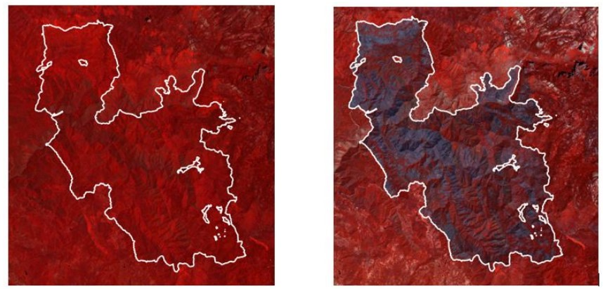

See the major contrast between the area within the fire boundaries and outside them?  
Wow!! The burned areas look gray because they are scorched bare.  
• On the ribbon, click the *Imagery* tab. In the *Analysis* group, choose *Raster Functions*

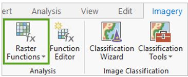

*Raster Functions Tool*  
On the *Systems* tab are categories of functions available for raster analysis. For this lesson, two raster function templates, or RFTs, were pre-created for use. These custom function templates are listed under the *Project* tab.  
• In the *Raster Functions* pane, click the *Custom* tab.  
• Navigate to your Data folder from CatCourses and open the Landcover_Remap and Burn_Severity.  
By opening these functions in a custom category, any edits you make to the RFTs will be saved if they are saved in the *Raster Function Editor*. Changes made in the Project category will be lost if the project is not saved. Save, save, save!  
• Right-click the *Burn_Severity* template and choose *Edit.*  
The *Raster Function Editor* (Fig 4) opens and displays the processing chain.

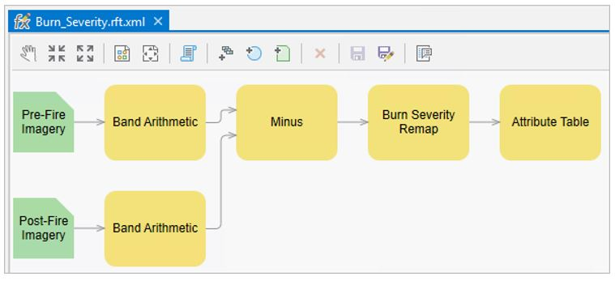

*The Raster Function Editor Window looks alot like ModelBuilder*  
The_ Band Arithmetic_ functions turn the pixels of the imagery into expressions. The post fire imagery is subtracted from the pre fire imagery and run through a remap function. The remap function categorizes the pixel values into five categories of burn severity. The breakpoints of the five burn severity values are obtained from a landscape assessment study (Key and Benson, 2005). The *Attribute Table* function in the processing chain assigns a color ramp to the burn severity map. This has already been created for you.  
• Close the *Burn Severity RFT* in the *Function Editor* window.  
• Back in the *Raster Functions* pane, click once on the *Burn_Severity* template. The Burn Severity inputs for the template open.  
• For Pre-Fire Imagery, choose FergusonBefore.tif, and for Post-Fire Imagery, choose FergusonAfter.tif.  
• Click *Create new layer*.  
The processing may take a few minutes to complete. When finished, the resulting layer is displayed in the map and listed in the *Contents* pane (below). Raster functions are temporary in nature—calculations are performed on the fly, or in real-time as you move the map, and are not saved automatically. Burn severity is computed dynamically in the display as you navigate around the layer.

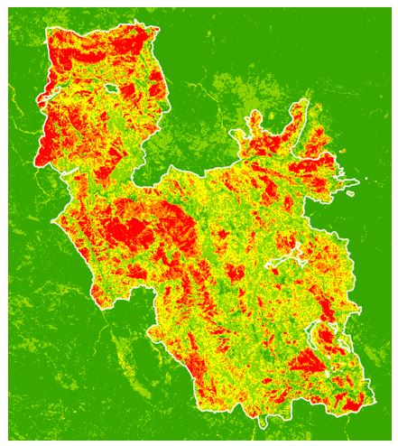

*Output Burn Severity Index*  
• Save the project.  
Take a screenshot [you do NOT have to make a full map for this portion] of the new Burn Severity raster output for submission.

### Part 3: Create a slope index map

The slope map is a critical layer in determining slope stability. Slope steepness is derived from a digital elevation model (DEM). The steeper the slope, the more prone it is to slipping, especially during a rainfall event after stabilizing vegetation has been burned away. Next, you’ll build and save a raster function template to calculate percent slope and use it to create a steepness index.  
• On the ribbon, click the *Imagery* tab. In the *Analysis* group, click *Function Editor*.  
• The *Function Editor* pane docks at the bottom of the map window.  
• In the *Raster Functions* pane, click the *System* tab. At the bottom of the list, expand the *Surface* group (Fig 6).

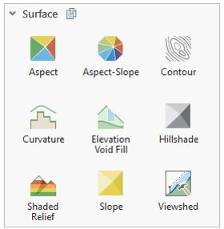

*The Surface group of tools in your Function Editor Pane*  
• Drag the *Slope* function into the *Raster Editor* pane (Fig 7).

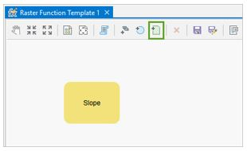

• In the *Function Editor* pane, on the ribbon, click *Add raster variable*.  
• A green box titled *Raster* is added to the *Function Editor* pane.  
• Make sure the green *Raster* box is positioned to the left of the *Slope* function box.  
• The *Raster* box will define the input dataset for the *Slope* function.  
• Hover over *Raster* to see the *Out parameter* displayed. Click *Out* and drag to connect the raster element (Out parameter) to the *Slope* function (DEM parameter).  
• Right-click *Raster* and click *Rename.* Type Input DEM.  
• Double-click the *Slope* function,then click *Variables*, and for DEM, check the *IsPublic* field (Fig 8).

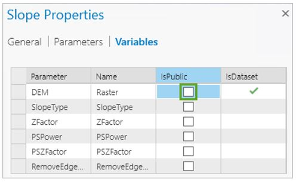

*Setting your Slope function properties*  
• The *IsPublic* option allows you to alter the input data in a later tool process.  
• Click *OK.*  
• In the *Raster Functions* pane, on the *System* tab, search for *Remap.*  
• The *Conversion* functions open.  
• Drag the *Remap* function into the *Function Editor* pane to the right of the *Slope* function.  
• Connect *Slope* to *Remap* by setting the output of Slope to the *Raster* input for *Remap*.

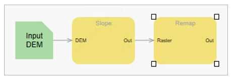

*Connecting your functions*  
• You’ll set the inputs for the remap to index the slopes (in units of degrees) into five categories.  
• Double-click the *Remap* function. In the *Remap Properties* tool window, under *General*, set the *Pixel Output type* to 16-bit unsigned.  
•In the *Remap* Properties tool window, click the first box under the Minimum column and type 0. For Maximum, type 5, and for Output, type 1 (Fig 10).  
• Set the categories with the following values then click OK.

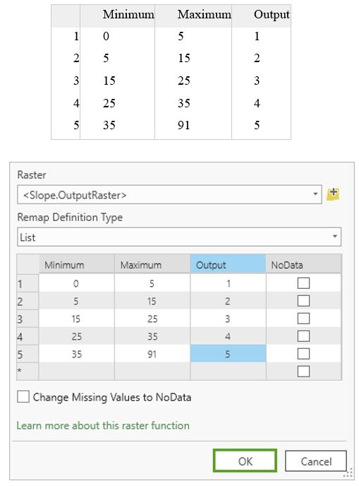

*Inputs for your Raster settings*  
• Right-click the *Remap* function and choose *Rename* Type Slope Remap.  
• This will help distinguish between functions later in this lesson when you string several raster function chains together.  
• In the Raster Functions pane, search for the *Attribute Table* function and drag it into the *Function Editor* pane.  
• Connect the output from the *Remap* function to the input of the *Attribute Table* function.  
• Double-click the *Attribute Table* function and set Table Type to Manual.  
• Under the blank table, click the color scheme button (Fig 11) and set Maximum Value to 5. Click OK.

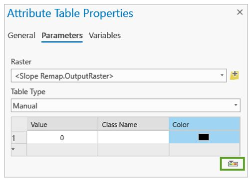

*Beginning the Attribute Table Parameter entries (before)*  
• Five rows are added with values 1 to 5 and a default green-to-red color scheme.  
• Click *Class Name* for each row and assign them as follows:

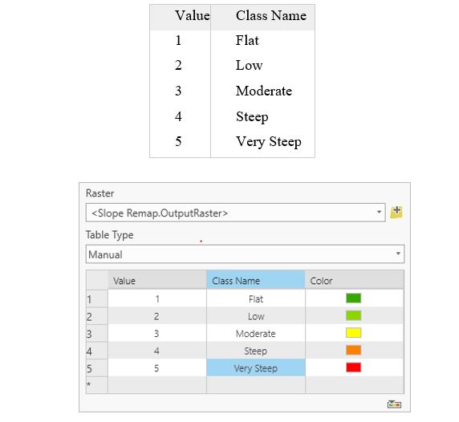

*After setting your color scheme and class info*  
Tip: Use the *Auto Layout* button (Fig 13) when all inputs and tools are connected to automatically arrange the elements in the diagram.

[figure not shown]

*We love the auto layout button!*  
• In the *Function Editor*, click *Save as*. In the *Save* window, name the RFTSlopeIndex and make sure Category is set to Custom.  
• Type a brief description and click OK.  
• Your RFT now appears in the *Custom* category in the *Raster Functions* pane.  
• Double Click your new function in the *Raster Functions* pane  
• Select the NED2013_mcd_mrp_albers.tif as the input raster and click *Create new layer*.  
• When it is finished processing, the layer displays on the map and is listed in the *Contents* pane. For this output, since we reclassified slope from our Digital Elevation Model (DEM), the darker red, the steeper the slope, with green being flat.

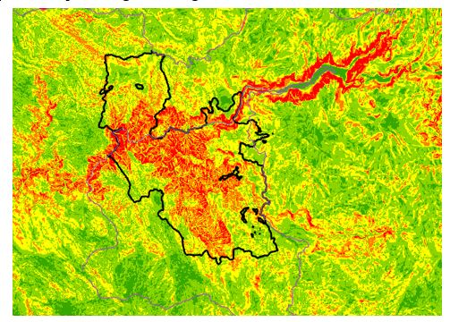

*Classified slope raster output*  
• Close the Slope_Index RFT in the *Function Editor* pane and save your project.  
Take a screenshot [you do NOT have to make a full map for this portion] of the new Slope Index raster output for submission.

### Part 4: Landslide Risk Calculation

The landslide risk calculation combines the two variables you just worked on: burn severity and slope. It also includes land cover, which is also important to landslide risk. Vegetation stabilizes slopes via root systems. Wildfire can wipe out much of the stabilizing vegetation. Some types of vegetation, especially species of chaparral, have adapted to wildfire, though, and the root systems are especially deep underground to survive fires. Land cover has already been indexed into five categories for you depending on its stabilizing effect on slopes. To perform the landslide risk calculation, you’ll add the three raster function templates into a chain that will be processed on your Raster Analytics deployment.  
• On the ribbon on the *Imagery* tab, click *Function Editor*.  
• A blank *Function Editor* pane opens.  
• In the *Raster Functions* pane, select and drag each RFT (Burn_Severity, Slope_Index, Landcover_Remap) into the *Function Editor* pane.  
• By default, the RFTs cluster together. You’ll want to separate them so that you can more easily connect their outputs.  
• Click and hold to draw a box around the *Slope_Index* functions, and then drag the entire group so that it’s below the *Burn_Severity* RFT (Fig 15).

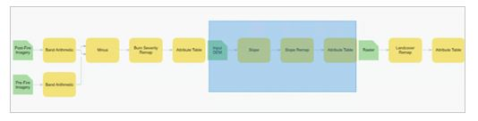

*Beginning to rearrange our functions*  
Tip: The green input boxes mark the beginning of each function chain.  
• Drag *Landcover_Remap* below *Slope_Index*.  
• In the *Raster Functions* pane, click the *System* tab and search for the *Weighted Overlay* function. Drag and drop it into the *Function Editor* pane to the right of the other three RFTs.  
• Connect the three *Attribute Table* outputs to the input parameter of the Weighted Overlay function by clicking once and dragging your mouse from Attribute Table to Weighted Overlay.  
• Right-click each *Attribute Table* function and rename it to correspond with the corresponding *Remap* function (e.g. Burn Severity Remap and Burn Severity Attribute Table).  
• Click the *Auto Layout* button to rearrange the boxes nicely (Fig 16).

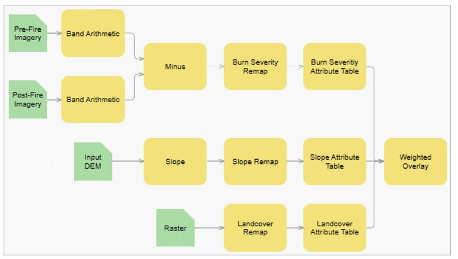

*Landslide risk function, almost complete.*  
• Double-click the *Weighted Overlay* function.  
• In the *Weighted Overlay Properties* window, for the Burn Severity Index layer, assign a weight of 30 percent; for the Slope Index layer, assign 55 percent; and for the Landcover Index layer, assign 15 percent.

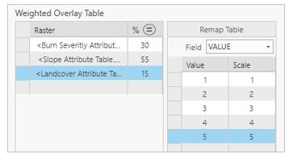

*Assigning weights and remap values*  
• The Remap table is still empty. Because all layers have the same number of index categories, each layer will be mapped one-to-one as shown in the example below. Hazard weights are loosely based on research done by the USGS for its Landslide Hazards Program.  
• In the *Weighted Overlay Table* window, click the Burn Severity layer. In the *Remap Table* window, for Value, click NODATA to edit the attribute field and type 1. Assign the corresponding Scale value to 1.  
• Click each box in the *Remap* table and assign the Value and Scale values (1–5). Repeat the process for each of the three rasters listed in the *Weighted Overlay Table* window.  
• Click OK.  
• In the *Raster Functions* pane, on the *System* tab, search for the *Attribute Table* function and drag it into the *Function Editor* pane to the right of the Weighted Overlay function.  
• Connect the output from the Weighted Overlay function to the input of the *Attribute Table* function.  
• Double-click the new *Attribute Table* function. In the *Attribute Table* *Properties* window, for Table Type, choose Manual.  
• Under the blank table, click the red-green color ramp button and set Maximum Value to 5.

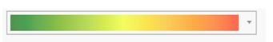

• Five rows are added with values 1 to 5 and a default green to red color scheme.  
• Click Class Name for each row and assign them as following:

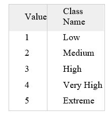

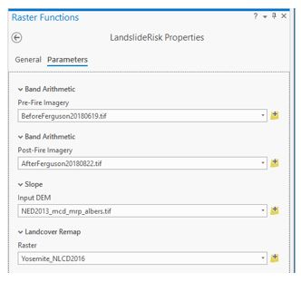

*Setting inputs for Landslide Risk Assessment*  
Answer: In a 3-4 sentences, what is NLCD?? Google this really quick for reference. What is the age of the most recent dataset (what year is the data from)? Why/why wouldn’t this be an issue if you need the imagery for a project?

• Click *Create new layer* to run your Raster Function. This may take several minutes because of the multiple large files.  
Upon completion, your new output raster, LandslideRisk, should look like the raster in the map below. NOTE: ArcGIS Pro may respond slowly due to the large file size.

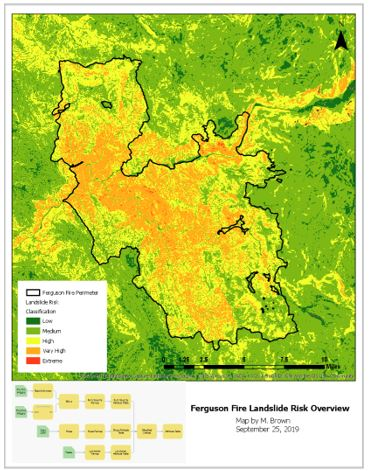

Submit a PRODUCTION QUALITY MAP focused on the Ferguson Fire perimeter with all appropriate key elements included. *Include a visual of your Landslide Risk Function*. The text must be clearly visible. Example above. Arrange your map layout however you prefer. It does not have to match this.  
This is the end point for Case Study 5-2.Good work!!

**BE SURE TO SAVE LAB 5-2 in your Classfiles folder. You WILL resume on this lab next week for 5-3.**

## Submission

At the end of this Case Study, you should have generated the following:  
•Screenshot of Burn Severity raster output  
•Screenshot of the new Slope Index raster output for submission.  
•Answer in a 3-4 sentences, what is NLCD?? Google this really quick for reference. Approximately how long might it take to receive data from this source? Why/why wouldn’t this be an issue if you need the imagery for a project?  
•Production quality map focused on the Ferguson Fire perimeter with all appropriate key elements included and legible text. Include a visual of your Landslide Risk Function.  
Put the above 4 bulleted submission points into a PDF and upload to CatCourses.

## References

1. Learn ArcGIS, Calculate Landslide Risk for Communities Affected by Wildfires. https://learn.arcgis.com/en/projects/calculate-landslide-risk-for-communities-affected-by-wildfires/
2. InciWeb. Ferguson Fire Overview. https://inciweb.nwcg.gov/incident/5927/